# Baseline_main

```r
if(!require("EBImage")){
  source("https://bioconductor.org/biocLite.R")
  biocLite("EBImage")
}

if(!require("gbm")){
  install.packages("gbm")
}

if(!require("caret")){
  install.packages("caret")
}

library("EBImage")
library("gbm")
```

### Step 0: specify directories.

Set the working directory to the image folder. Specify the training and the testing set. For data without an independent test/validation set, you need to create your own testing data by random subsampling. In order to obain reproducible results, set.seed() whenever randomization is used.

```r
set.seed(2019)
```

```r
train_dir <- "../data/train_set/"
train_LR_dir <- paste(train_dir, "LR/", sep="")
train_HR_dir <- paste(train_dir, "HR/", sep="")
train_label_path <- paste(train_dir, "label.csv", sep="")
```

### Step 1: set up controls for evaluation experiments.

In this chunk, we have a set of controls for the evaluation experiments.

- (T/F) cross-validation on the training set
- (number) K, the number of CV folds
- (T/F) process features for training set
- (T/F) run evaluation on an independent test set
- (T/F) process features for test set

```r
run.cv=TRUE # run cross-validation on the training set
K <- 5  # number of CV folds
run.feature.train=TRUE # process features for training set
run.test=TRUE # run evaluation on an independent test set
run.feature.test=TRUE # process features for test set
```

Setup the parameters

```r
# df -  is the feature combinations for baseline gbm
df <- data.frame(matrix(ncol = 3, nrow = 27))
x <- c("numTrees", "minNode", "shrinkage")
colnames(df) <- x

numTrees = seq(80, 100, 10)
minNode = seq(30, 50, 10)
shrinkage = seq(0.16, 0.2, 0.02)


df$numTrees <- rep(numTrees, each = length(minNode)*length(shrinkage))
df$minNode <- rep(rep(minNode, each = length(shrinkage)), length(numTrees))
df$shrinkage <- rep(shrinkage, length(numTrees)*length(minNode))

model_values <- df
```

### Step 2: import training images class labels.

We provide extra information of image label: car (0), flower (1), market (2). These labels are not necessary for your model.

Classify the training set by different labels

```r
labels <- read.csv(train_label_path)
```

```r
library(dplyr)
getimg <- function(label, direc){
  temp <- labels %>% filter(Label==label) %>% select(Image)
  temp <- as.character(temp$Image)

  imgLR <- list()
  for(i in 1:length(temp)){
  imgLR0 <- as.array(readImage(paste0(direc,  "img_", temp[i])))
  imgLR[[i]] <- imgLR0
  }
  return(imgLR)
}

imgLR_0 <- getimg(0, train_LR_dir)
imgLR_1 <- getimg(1, train_LR_dir)
imgLR_2 <- getimg(2, train_LR_dir)

imgHR_0 <- getimg(0, train_HR_dir)
imgHR_1 <- getimg(1, train_HR_dir)
imgHR_2 <- getimg(2, train_HR_dir)
```

Save the LR, HR img information in different RData files.

```r
save(imgLR_0,imgLR_1,imgLR_2,file = "imgLR.RData")
save(imgHR_0,imgHR_1,imgHR_2,file = "imgHR.RData")
```

```r
load("imgLR.RData")
load("imgHR.RData")
```

### Step 3: construct features and responses

`feature.R` should be the wrapper for all your feature engineering functions and options. The function `feature( )` should have options that correspond to different scenarios for your project and produces an R object that contains features and responses that are required by all the models you are going to evaluate later. + `feature.R` + Input: a path for low-resolution images. + Input: a path for high-resolution images. + Output: an RData file that contains extracted features and corresponding responses

```r
source("../lib/feature.R")

tm_feature_train <- NA
if(run.feature.train){
  tm_feature_train <- system.time(dat_train <- feature(imgLR_0, imgHR_0))
  feat_train0 <- dat_train$feature
  label_train0 <- dat_train$label
}

save(dat_train, file="../output/feature_train0.RData")
```

```r
tm_feature_train <- NA
if(run.feature.train){
  tm_feature_train <- system.time(dat_train <- feature(imgLR_1, imgHR_1))
  feat_train1 <- dat_train$feature
  label_train1 <- dat_train$label
}

save(dat_train, file="../output/feature_train1.RData")
```

```r
if(run.feature.train){
  tm_feature_train <- system.time(dat_train <- feature(imgLR_2, imgHR_2))
  feat_train2 <- dat_train$feature
  label_train2 <- dat_train$label
}

save(dat_train, file="../output/feature_train1.RData")
```

### Step 4: Train a classification model with training images

Call the train model and test model from library.

`train.R` and `test.R` should be wrappers for all your model training steps and your classification/prediction steps. + `train.R` + Input: training set features and responses. + Output: an RData file that contains trained classifiers in the forms of R objects: models/settings/links to external trained configurations. + `test.R` + Input: a path that points to the test set features. + Input: an R object that contains a trained classifier. + Output: an R object of response predictions on the test set. If there are multiple classifiers under evaluation, there should be multiple sets of label predictions.

```r
source("../lib/train_baseline.R")
source("../lib/test_baseline.R")
```

#### Model selection with cross-validation

- Do model selection by choosing among different values of training model parameters. If the interaction depth for GBM is large, it is time consuming, even though we can get better results, we set depth = 1. We tried different values of numTrees, minNode, shrinkage for GBM with different labels in this section. It cost nearly 32 hours to select parameters for GBM.

```r
source("../lib/cross_validation_baseline.R")

if(run.cv){
  err_cv <- array(dim=c(nrow(model_values), 2))
  for(k in 1:nrow(model_values)){
    print(paste('Currently evaluating parameter combination ', k))

    cat("k=", k, "\n")
    err_cv[k,] <- cv.function(feat_train0, label_train0,  K, depth = 1,
                              numTrees = model_values$numTrees[k] ,
                              minNode = model_values$minNode[k] ,
                              shrinkage = model_values$shrinkage[k])
  }
  save(err_cv, file="../output/err_cv_baseline0.RData")
}
```

```r
if(run.cv){
  err_cv <- array(dim=c(nrow(model_values), 2))
  for(k in 1:nrow(model_values)){
    print(paste('Currently evaluating parameter combination ', k))

    cat("k=", k, "\n")
    err_cv[k,] <- cv.function(feat_train1, label_train1,  K, depth = 1,
                              numTrees = model_values$numTrees[k] ,
                              minNode = model_values$minNode[k] ,
                              shrinkage = model_values$shrinkage[k])
  }
  save(err_cv, file="../output/err_cv_baseline1.RData")
}
```

```r
if(run.cv){
  err_cv <- array(dim=c(nrow(model_values), 2))
  for(k in 1:nrow(model_values)){
    print(paste('Currently evaluating parameter combination ', k))

    cat("k=", k, "\n")
    err_cv[k,] <- cv.function(feat_train2, label_train2,  K, depth = 1,
                              numTrees = model_values$numTrees[k] ,
                              minNode = model_values$minNode[k] ,
                              shrinkage = model_values$shrinkage[k])
  }
  save(err_cv, file="../output/err_cv_baseline2.RData")
}
```

Visualize cross-validation results for different labels. *cars

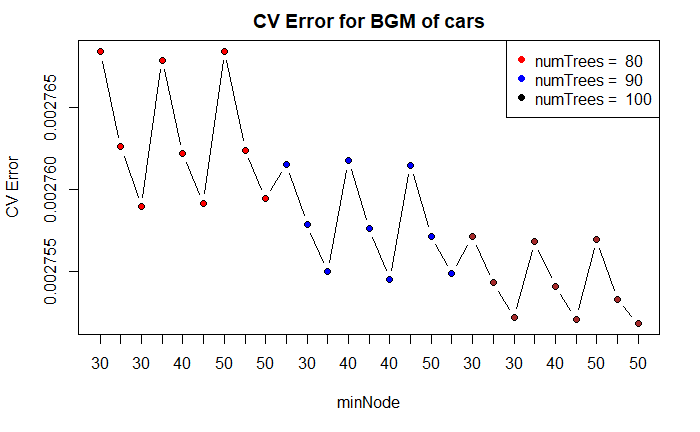

```r
if(run.cv){
  load("../output/err_cv_baseline0.RData")
  plot(1:27, err_cv[,1], xlab="minNode", ylab="CV Error",
     main="CV Error for BGM of cars", type="n",xaxt = "n")
  axis(1, at=seq(1,27,by=1), labels=df$minNode)
  points(1:9, err_cv[1:9,1], col="red", pch=16)
  points(10:18, err_cv[10:18,1], col="blue", pch=16)
  points(19:27, err_cv[19:27,1], col="brown", pch=16)
  lines(1:27, err_cv[,1], col="black", type = 'b')
  legend("topright", legend=paste('numTrees = ', levels(as.factor(df$numTrees)) ), pch=16, col=c("red", "blue", "black"))
}
```

*flowers

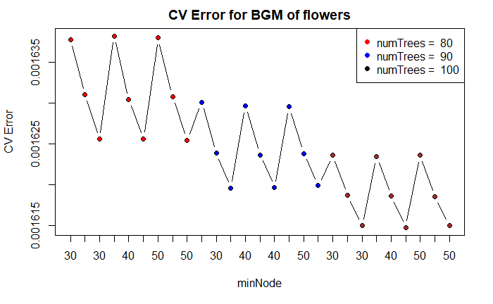

```r
if(run.cv){
  load("../output/err_cv_baseline1.RData")
  plot(1:27, err_cv[,1], xlab="minNode", ylab="CV Error",
     main="CV Error for BGM of flowers", type="n",xaxt = "n")
  axis(1, at=seq(1,27,by=1), labels=df$minNode)
  points(1:9, err_cv[1:9,1], col="red", pch=16)
  points(10:18, err_cv[10:18,1], col="blue", pch=16)
  points(19:27, err_cv[19:27,1], col="brown", pch=16)
  lines(1:27, err_cv[,1], col="black", type = 'b')
  legend("topright", legend=paste('numTrees = ', levels(as.factor(df$numTrees)) ), pch=16, col=c("red", "blue", "black"))
}
```

*markets

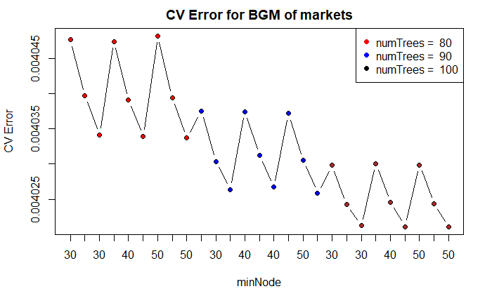

```r
if(run.cv){
  load("../output/err_cv_baseline2.RData")
  plot(1:27, err_cv[,1], xlab="minNode", ylab="CV Error",
     main="CV Error for BGM of markets", type="n",xaxt = "n")
  axis(1, at=seq(1,27,by=1), labels=df$minNode)
  points(1:9, err_cv[1:9,1], col="red", pch=16)
  points(10:18, err_cv[10:18,1], col="blue", pch=16)
  points(19:27, err_cv[19:27,1], col="brown", pch=16)
  lines(1:27, err_cv[,1], col="black", type = 'b')
  legend("topright", legend=paste('numTrees = ', levels(as.factor(df$numTrees)) ), pch=16, col=c("red", "blue", "black"))
}
```

- Choose the “best” parameter value of “cars”

```r
if(run.cv){
  load("../output/err_cv_baseline0.RData")
  model_best <- model_values[which.min(err_cv[,1]),]
}
par_best0 <- list(depth = 1, numTrees = model_best$numTrees, minNode = model_best$minNode,  shrinkage=model_best$shrinkage)
min(err_cv[,1])
```

```
[1] 0.00275185
```

```r
20 * log10(1) - 10 * log10(min(err_cv[,1]))
```

```
[1] 25.60375
```

```r
par_best0
```

```
$`depth`
[1] 1

$numTrees
[1] 100

$minNode
[1] 50

$shrinkage
[1] 0.2
```

- Choose the “best” parameter value of “flowers”

```r
if(run.cv){
  load("../output/err_cv_baseline1.RData")
  model_best <- model_values[which.min(err_cv[,1]),]
}
par_best1 <- list(depth = 1, numTrees = model_best$numTrees, minNode = model_best$minNode,  shrinkage=model_best$shrinkage)
min(err_cv)
```

```
[1] 6.30991e-06
```

```r
20 * log10(1) - 10 * log10(min(err_cv[,1]))
```

```
[1] 27.91894
```

```r
par_best1
```

```
$`depth`
[1] 1

$numTrees
[1] 100

$minNode
[1] 40

$shrinkage
[1] 0.2
```

- Choose the “best” parameter value of “markets”

```r
if(run.cv){
  load("../output/err_cv_baseline2.RData")
  model_best <- model_values[which.min(err_cv[,1]),]
}
par_best2 <- list(depth = 1, numTrees = model_best$numTrees, minNode = model_best$minNode,  shrinkage=model_best$shrinkage)
min(err_cv[,1])
```

```
[1] 0.00402111
```

```r
20 * log10(1) - 10 * log10(min(err_cv[,1]))
```

```
[1] 23.95654
```

```r
par_best2
```

```
$`depth`
[1] 1

$numTrees
[1] 100

$minNode
[1] 50

$shrinkage
[1] 0.2
```

For data labeled “flowers”, GBM model has best performance with PSNR 27.92.